# DCS Assignments session 6

### Answers

- Adding a value which occurs in just 1 series (whether it is `-2`, or `0`), but not the other makes sure that value will not be recurring in a Cross Recurrence Plot

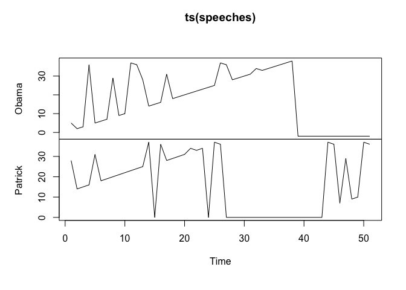

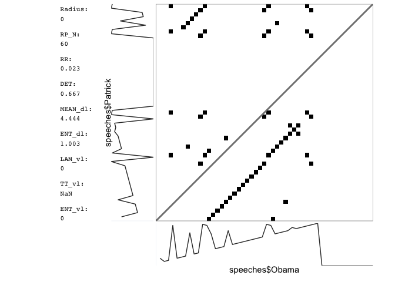

```r
# Plot the speech series
plot(ts(speeches))

# Cross recurrence matrix
RM <- rp(y1 = speeches$Obama, y2 = speeches$Patrick, emDim = 1, emLag = 1, emRad = 0)

# Measures
crqa_out <- crqa_rp(RM)
# Plot
rp_plot(RM, plotDimensions = TRUE, plotMeasures = TRUE)
```

```r
# Diagonal profile
crqa_diagProfile(RM,diagWin = 40)
```

```
##
## Profile 1
```

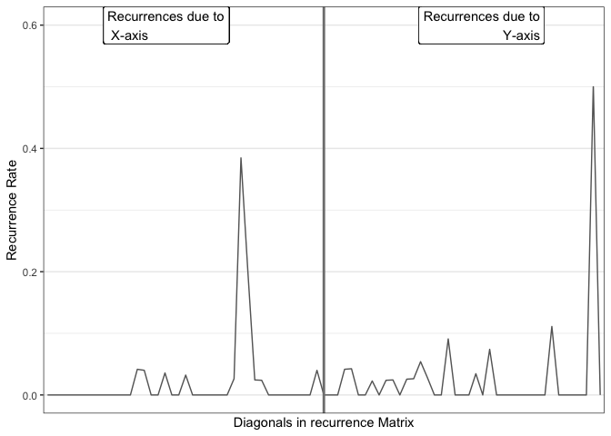

## 6.2 Continuous CRQA and the Diagonal Profile

### Questions

- Create two sinewave variables for CRQA analysis and use the $x$ and $y$ coordinates of the circletracing data:

```r
y1 <- sin(1:500*2*pi/67)
y2 <- sin(.01*(1:500*2*pi/67)^2)

# Here are the circle trace data
xy <- import("https://raw.githubusercontent.com/FredHasselman/The-Complex-Systems-Approach-Book/master/assignments/assignment_data/RQA_circletrace/mouse_circle_xy.csv")

circle_x <- xy$x[1:500]
circle_y <- xy$y[1:500]
```

### Answers

- You have just created two sine(-like) waves. We’ll examine if and how they are coupled in a shared phase space.
- As a first step plot them.
- Also plot the cirlce trace state space

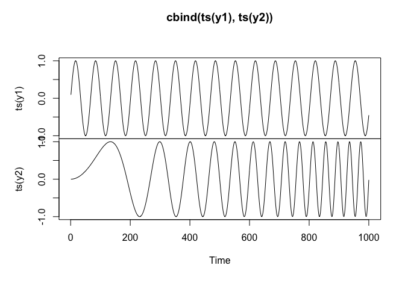

```r
library(rio)
y1 <- sin(1:1000*2*pi/67)
y2 <- sin(.01*(1:1000*2*pi/67)^2)

# Here are the circle trace data
xy <- import("https://raw.githubusercontent.com/FredHasselman/The-Complex-Systems-Approach-Book/master/assignments/assignment_data/RQA_circletrace/mouse_circle_xy.csv")

circle_x <- xy$x[1:1000]
circle_y <- xy$y[1:1000]

# Time series
plot(cbind(ts(y1),ts(y2)))
```

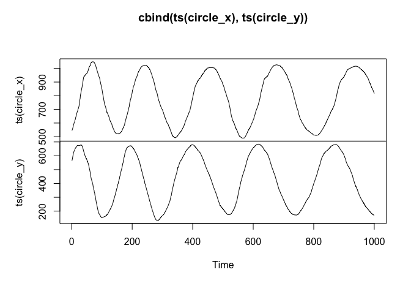

```r
plot(cbind(ts(circle_x),ts(circle_y)))
```

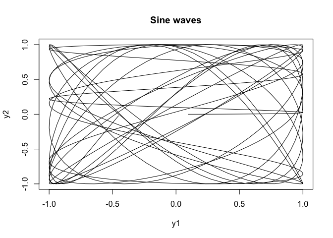

```r
# State space
plot(y1,y2,type="l", pty="s",main = "Sine waves")
```

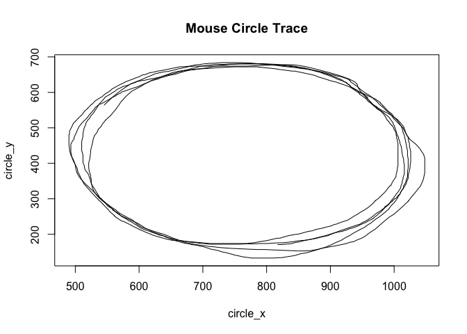

```r
plot(circle_x,circle_y,type="l", pty="s",main = "Mouse Circle Trace")
```

- Find a common embedding delay and an embedding dimension (if you calculate an embedding dimension for each signal separately, as a rule of thumb use the highest embedding dimension you find in further analyses).

```r
params_y1 <- crqa_parameters(y1)
```

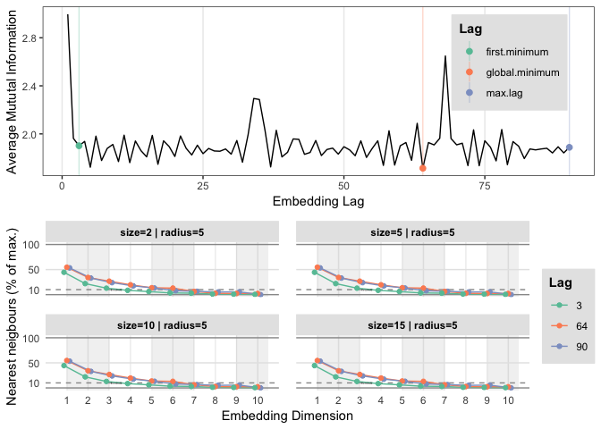

```r
params_y2 <- crqa_parameters(y2)
```

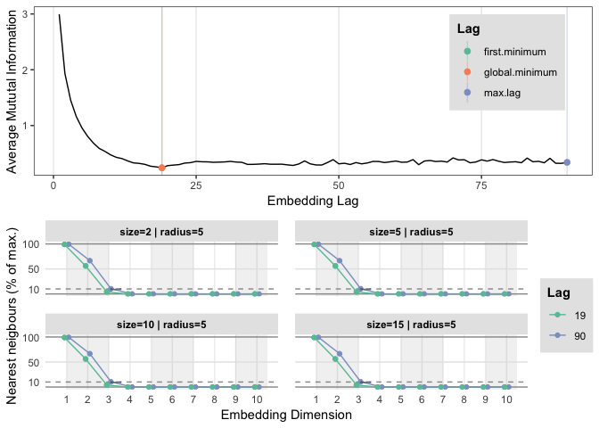

> The diagnostic plot of the sine wave `y1` looks a bit odd. This is due to the fact that mutual information will discretize the time series, and the sine will fill all bins with the same values, because it is perfectly repeating itself. We’ll use emDim = 2 and lag = 1

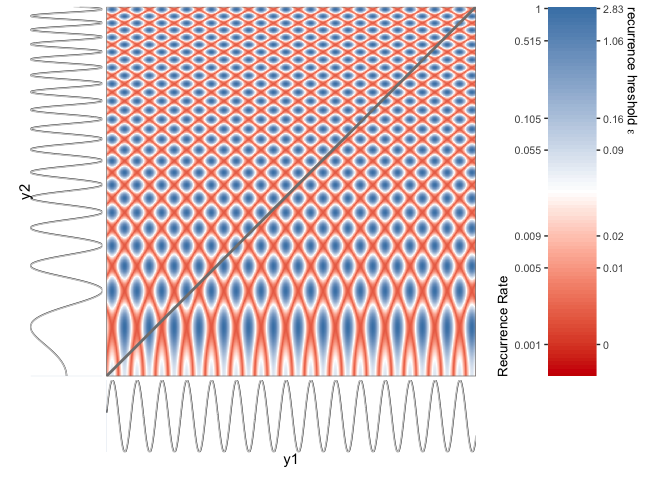

```r
emLag <- 1
emDim <- 2

RM <- rp(y1=y1, y2=y2,emDim = emDim, emLag = emLag)

# Unthresholded Matrix
rp_plot(RM, plotDimensions = TRUE)
```

```r
# Thresholded Matrix, based on 5% RR
emRad <- crqa_radius(RM = RM, targetValue = .05)$Radius
```

```
##
## Searching for a radius that will yield 0.05 for RR
```

```
##
## Converged! Found an appropriate radius...
```

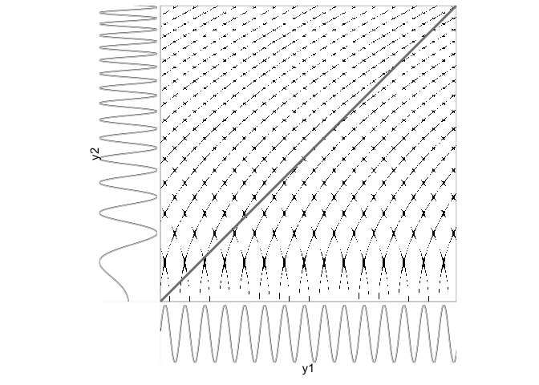

```r
RP <- di2bi(RM, emRad = emRad)
rp_plot(RP, plotDimensions = TRUE)
```

```r
# The diagonal profile
drp <- crqa_diagProfile(RP, diagWin = 50)
```

```
##
## Profile 1
```

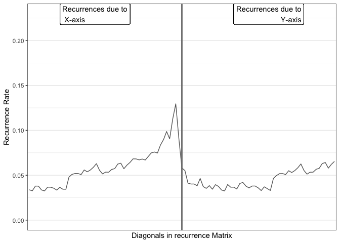

```r
# Compare CRQA with one randomly shuffled series
drpRND <- crqa_diagProfile(RP, diagWin = 50, doShuffle = TRUE, y1 = y1, y2 = y2, Nshuffle = 19)
```

```
## Calculating diagonal recurrence profiles...
##
## Profile 1
## Profile 2
## Profile 3
## Profile 4
## Profile 5
## Profile 6
## Profile 7
## Profile 8
## Profile 9
## Profile 10
## Profile 11
## Profile 12
## Profile 13
## Profile 14
## Profile 15
## Profile 16
## Profile 17
## Profile 18
## Profile 19
## Profile 20
```

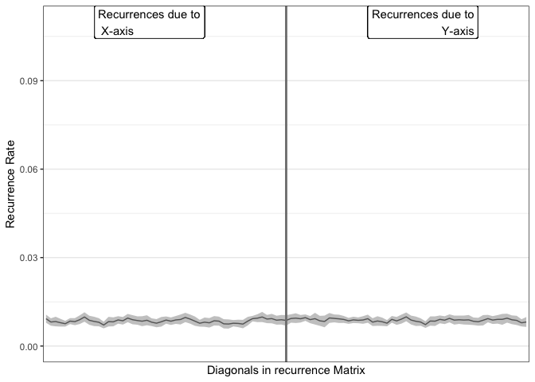

```r
params_cx <- crqa_parameters(circle_x)
```

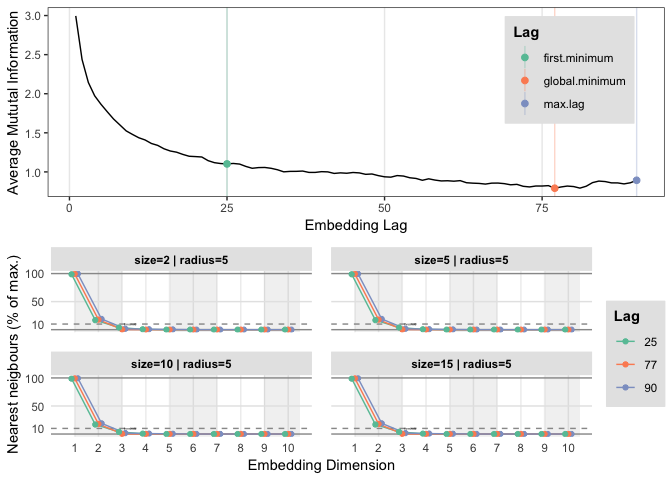

```r
params_cy <- crqa_parameters(circle_y)
```

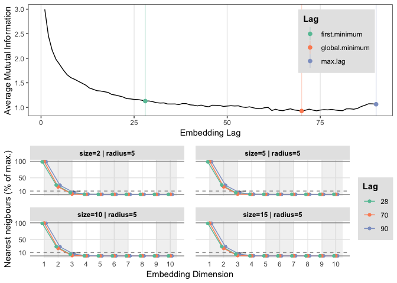

> The circle trace data can be embedded in 3 dimensions. This is not so strange, even though the circle was drawn in 2 dimensions, there are also speed/acceleration and accuracy constraints.

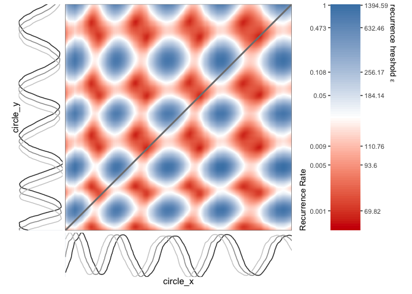

```r
emLag <- median(params_cx$optimLag, params_cy$optimLag)
emDim <- max(params_cx$optimDim, params_cy$optimDim)

RM <- rp(y1=circle_x, y2=circle_y,emDim = emDim, emLag = emLag)

# Unthresholded Matrix
rp_plot(RM, plotDimensions = TRUE)
```

```r
# Thresholded Matrix, based on 5% RR
emRad <- crqa_radius(RM = RM, targetValue = .05)$Radius
```

```
##
## Searching for a radius that will yield 0.05 for RR
```

```
##
## Converged! Found an appropriate radius...
```

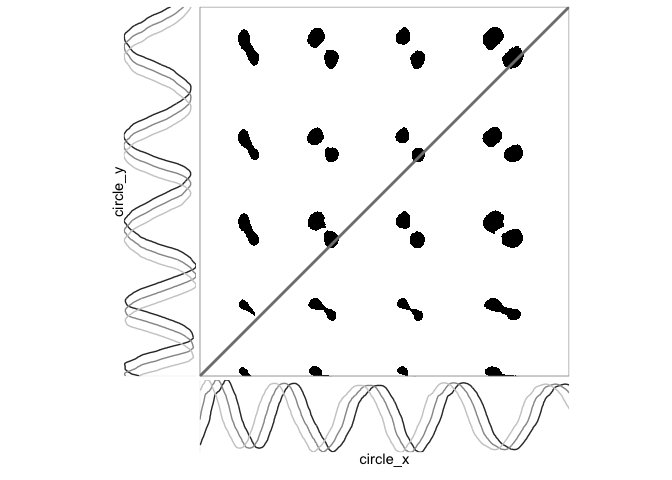

```r
RP <- di2bi(RM, emRad = emRad)
rp_plot(RP, plotDimensions = TRUE)
```

```r
# The diagonal profile
drp <- crqa_diagProfile(RP, diagWin = 100)
```

```
##
## Profile 1
```

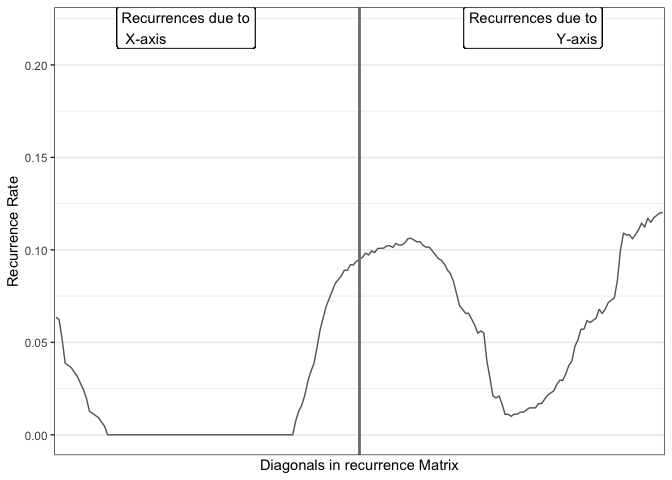